# Problem-set 4

[202014837] Andres Silva & [202022380] Juan Walteros

2024-06-05

```r
knitr::opts_chunk$set(echo = TRUE)

rm(list=ls())

require(pacman)
```

```r
p_load(pacman, rio, data.table, tidyverse,
       sf, rvest, ggplot2,
       mapview, tmaptools, osmdata, viridis, skimr)
```

# Problem-Set 4

Esta página contiene todo el código del último problem set del curso.

# 1. Extraer información de internet:

#### 1.1. Obtener las URL

```r
#1.1.
url <- "https://eduard-martinez.github.io/pset-4.html"

html <- read_html(url)

table <- html %>% html_table()
table <- table[[1]]
url_full <- as.matrix(table$url)
## Al haber extrído las urls de la tabla, ya aseguramos que solo están las que contienen
# la extensión de propiedad. Por esto, url_subset = url_full
```

#### 1.2. Filtrar las URL

```r
## Al haber extrído las urls de la tabla, ya aseguramos que solo están las que contienen
# la extensión de propiedad. Por esto, url_subset = url_full

url_subset <- url_full
```

#### 1.3. Extraer las tablas de los HTML:

```r
lista_tablas <- list()

for (i in 1:length(url_subset)) {

  htread <- read_html(url_subset[i])

  lista_tablas[i] <- html_table(htread)

}
```

#### 1.4. Preparar información:

```r
db_house <- rbindlist(lista_tablas, fill=TRUE, idcol=TRUE)
```

# 2. Manipular información GIS:

#### 2.1. Cree un objeto sf:

```r
sf_house <- st_as_sf(db_house, coords = c("lon","lat"), crs = 4326)
```

#### 2.2. Pintar mapa:

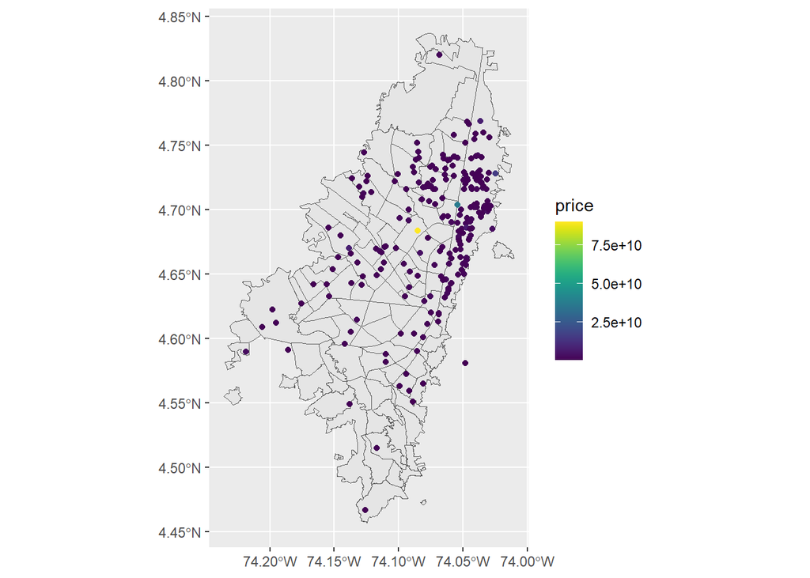

```r
bog <- opq(bbox = getbb("Bogota Colombia")) %>%
       add_osm_feature(key="boundary", value="administrative") %>%
       osmdata_sf()
bog <- bog$osm_multipolygons %>% subset(admin_level==9 & !osm_id %in% 16011743:16011744)



house_map <- ggplot() +   geom_sf(mapping = aes(),data = bog) + geom_sf(mapping = aes(color = price), data = sf_house) + scale_color_viridis(option = "D")

ggsave("output/house_map.png", plot = house_map, width = 10, height = 8, dpi = 300)
file.show("house_map.png")

ggplot() +   geom_sf(mapping = aes(),data = bog) + geom_sf(mapping = aes(color = price), data = sf_house) + scale_color_viridis(option = "D") ##Esto lo puse al final solo para que se pueda visualizar en la página.
```

# 3. Bonos:

#### 3.1 R-Markdown: todo fue realizado en RMD

#### Estadísticas descriptivas:

```r
summary(db_house)
```

```
##       .id               V1               V1             rooms
##  Min.   :  1.00   Min.   :   679   Min.   :   679   Min.   : 1.000
##  1st Qu.: 55.75   1st Qu.: 54061   1st Qu.: 54061   1st Qu.: 2.000
##  Median :110.50   Median :111370   Median :111370   Median : 3.000
##  Mean   :110.50   Mean   :114243   Mean   :114243   Mean   : 2.975
##  3rd Qu.:165.25   3rd Qu.:171246   3rd Qu.:171246   3rd Qu.: 3.000
##  Max.   :220.00   Max.   :238654   Max.   :238654   Max.   :12.000
##                                                     NA's   :139
##     bedrooms        bathrooms      surface_total    surface_covered
##  Min.   : 0.000   Min.   : 1.000   Min.   :  35.0   Min.   :   35.00
##  1st Qu.: 2.000   1st Qu.: 2.000   1st Qu.:  70.0   1st Qu.:   70.75
##  Median : 3.000   Median : 2.000   Median : 109.0   Median :  108.00
##  Mean   : 3.127   Mean   : 2.593   Mean   : 248.1   Mean   :  401.01
##  3rd Qu.: 3.000   3rd Qu.: 3.000   3rd Qu.: 218.0   3rd Qu.:  188.25
##  Max.   :12.000   Max.   :10.000   Max.   :3340.0   Max.   :21424.00
##  NA's   :149      NA's   :43       NA's   :155      NA's   :136
##      price           property_type           lat             lon
##  Min.   :1.900e+07   Length:220         Min.   :4.467   Min.   :-74.22
##  1st Qu.:3.000e+08   Class :character   1st Qu.:4.653   1st Qu.:-74.09
##  Median :4.775e+08   Mode  :character   Median :4.693   Median :-74.06
##  Mean   :1.400e+09                      Mean   :4.683   Mean   :-74.07
##  3rd Qu.:8.885e+08                      3rd Qu.:4.723   3rd Qu.:-74.05
##  Max.   :9.000e+10                      Max.   :4.820   Max.   :-74.02
##
##    geometry
##  Length:220
##  Class :character
##  Mode  :character
##
##
##
##
```

En este summarize se pueden ver las estadísticas descriptivas preliminares de los datos de propiedades almacenados en las páginas web. En cuanto a las habitaciones, se puede ver que hay propiedades con solo una “room”, así como hay algunos (o solo uno) con 12. No obstante, se puede ver que la media es de tres “rooms”, y de acuerdo a los percentiles, encontrar una con un alto número de “rooms” como la de 12 es algo difícil en esta muestra. Lo mismo ocurre con los baños y los cuartos. Es importante notar que hay un mínimo de cero en los cuartos, lo que indica que hay una(s) edificacion(es) sin este espacio.

```r
db_house <- db_house[,-3]##No permite ejecutar el group by si V1 esta duplicada.
db_house %>% group_by(bedrooms) %>%  summarise(frecuencia = n())
```

```
## # A tibble: 11 × 2
##    bedrooms frecuencia
##       <int>      <int>
##  1        0          2
##  2        1          3
##  3        2         16
##  4        3         36
##  5        4          7
##  6        5          1
##  7        6          2
##  8        7          2
##  9        8          1
## 10       12          1
## 11       NA        149
```

Para complementar lo dicho anteriormente, y ver como se distribuyen las viviendas según sus características, de hizo esta tabla de frecuencias. Se puede ver que las propiedades sin cuarto de dormir son 2, y que la gran mayoría se centra en 2, 3 y 4 habitaciones.

```r
db_house %>% group_by(rooms) %>%  summarise(frecuencia = n())
```

```
## # A tibble: 8 × 2
##   rooms frecuencia
##   <int>      <int>
## 1     1          8
## 2     2         15
## 3     3         43
## 4     4         10
## 5     5          2
## 6     6          2
## 7    12          1
## 8    NA        139
```

De igual forma, las “rooms” también se concentran en estos valores, aunque no hay ninguno con cero “rooms”. Hay que notar que hay demasiados missing values, más de la mitad de la muestra son missing values para esta variable.

```r
db_house %>% group_by(bathrooms) %>%  summarise(frecuencia = n())
```

```
## # A tibble: 9 × 2
##   bathrooms frecuencia
##       <int>      <int>
## 1         1         29
## 2         2         70
## 3         3         45
## 4         4         23
## 5         5          3
## 6         6          5
## 7         8          1
## 8        10          1
## 9        NA         43
```

No hay propiedades sin baño, y se puede ver que la mayoría tienen de 1 a 4 baños. Esta variable tiene bastantes missing values, aunque no tantos como las otras.

```r
db_house %>% group_by(property_type) %>%  summarise(frecuencia = n())
```

```
## # A tibble: 8 × 2
##   property_type   frecuencia
##   <chr>                <int>
## 1 Apartamento            112
## 2 Casa                    45
## 3 Depósito                 5
## 4 Local comercial          2
## 5 Lote                     1
## 6 Oficina                 15
## 7 Otro                    38
## 8 Parqueadero              2
```

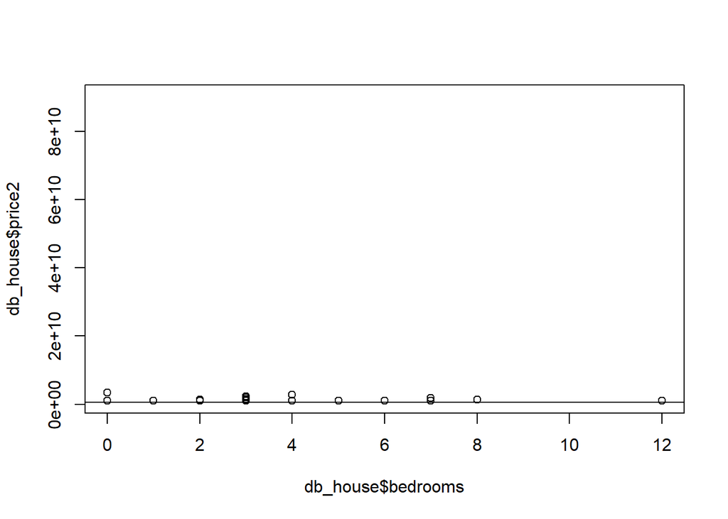

```r
lmodelo <- lm(db_house$price ~ db_house$bedrooms)

db_house$price2 <- ifelse(db_house$price < 1000000000, 1000000000, db_house$price) ##restrinjo la muestra osino el gráfico queda en escalas muy grandes.

plot(db_house$bedrooms, db_house$price2)
abline(a=coef(lmodelo)[1], b=coef(lmodelo)[2])
```

Es difícil establecer una relación visual porque los precios son muy volátiles y el número de cuartos de dormir se acumula entre valores muy pequeños.

```r
coef(lmodelo)[2] ## Este es el "beta" de regresión. En este caso nos explica solo una correlación, y es positiva
```

```
## db_house$bedrooms
##           3384418
```

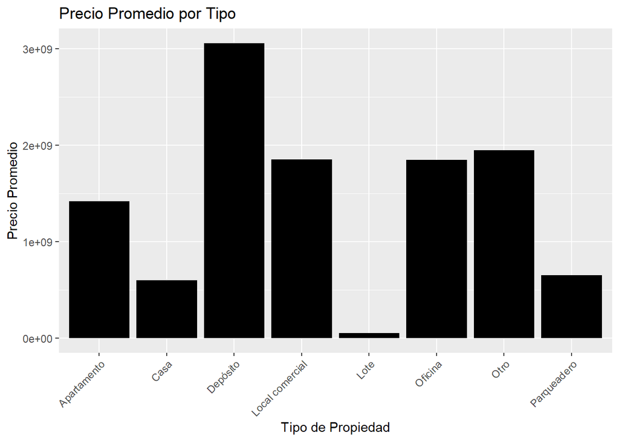

```r
ggplot(db_house, aes(x = property_type, y = price)) +
  stat_summary(fun = mean, geom = "bar", fill = "black") +
  labs(title = "Precio Promedio por Tipo",
       x = "Tipo de Propiedad",
       y = "Precio Promedio")+
  theme(axis.text.x = element_text(angle = 45, hjust = 1))
```

en este caso de barras, se ilustra el precio promedio por cada tipo de propiedad. En este caso, los lotes son los de menor valor y los depositos los de mayor valor.

#### 3.2. HTML en github:

[Link hacia el repositorio de la página](https://github.com/AndresSilva03/AndresSilva03.github.io)

```r
export(db_house,"output/db_house.rds")
```